# Memo - Inflection Points

Roxanne Ready

9/6/2019

# Memo - Inflection Points

- Paper name: “Inflection points in community-level homeless rates”
- [Source](https://wp.zillowstatic.com/3/Inflection_Points_20181213-ee1463.pdf)
- Organization: real estate analytics firm Zwillo
- Authors:
  - Chris Glynn, Paul College of Business and Economics, University of New Hampshire, christopher.glynn@unh.edu
  - Thomas H. Byrne, School of Social Work, Boston University, tbyrne@bu.edu
  - Dennis P. Culhane, School of Social Policy & Practice, University of Pennsylvania, culhane@upenn.edu

## Methodology Notes

- **Six clusters of communities defined**: The researchers used “partitions [of] communities into clusters where the relationship between rates of homelessness and features of communities is common” (Introduction, p. 2), for a total of six clusters, three of which contain the vast majority of the communities (381 of 386). Cluster assignments can be found on GitHub: https://github.com/G-Lynn/Inflection/
  - Cluster 1: “primarily located in the **midwest, mid-Atlantic, and southeast** – tend to have very low homeless rates and modest housing costs” (Introduction, p. 3, emphasis added)
  - Cluster 2: “including most of **New England, Florida, the mountain west and central United States** – have intermediate homeless rates and housing costs on par with the national average”(Introduction, p. 3, emphasis added)
  - Cluster 3: “span **much of the west coast and include large metropolitan areas on the east coast**, have very high homeless rates and high costs of housing.” (Introduction, p. 3, emphasis added)
  - Cluster 4: one member, “El Dorado County CoC, which is unique because it has a high homeless rate but modest housing costs and low poverty rates” (p. 15)
  - Cluster 5: three members, “the Southeast Arkansas, Houma-Terrebonne/Thibodaux (Louisiana), and Central Tennessee CoCs (see Figure 4). In these communities, the average homeless rate is very low (0.03%) considering the high rate of extreme poverty (7.96%)” (p. 15)
  - Cluster 6: one member, “the Marin County CoC in the San Francisco Bay area, which stands out for its particularly strong association between the homeless rate and worsening housing affordability” (p. 15)
- **Researchers focused on the following three features** and their interactions with each other:
  - rental costs
  - median household income
  - percent of residents living in extreme poverty
- **Affordability defined**: “the percent of income spent on housing costs – more completely reflects the relative affordability of housing across communities, taking into account that high rents in big cities are also typically supported by relatively higher salaries whereas lower rents in rural areas may still represent a significant portion of one’s income.” (Introduction, p. 3)
- **Reasons for focus on limited features**: “While countless features of a community are potentially associated with homelessness – including apartment vacancy rates, unemployment rates, demographics, etc. – most (if not all) are highly correlated with the features that we have included in our analysis: cost of rental housing, median income, and rates of extreme poverty. Including many highly correlated predictors in a statistical model presents estimation problems that are avoided by focusing on a few important predictive features.” (Data, p. 4-5)

## Findings

- **When rental costs excede 32% of median income, homelessness begins to increase more sharply**: “expected homeless rate in a community increases sharply once median rental costs exceed 32% of median income, providing empirical evidence for the widely used definition of a housing cost burden at 30% of income.” (Abstract, p. 1)
- **Affordability is a probable cause of unequal homelessness growth nationally**: “The average housing affordability metric is higher in cluster three (38.44%) than the 32% break point we identify – which partly explains rapid growth in the homeless populations of many of these CoCs. … the majority of the United States is less sensitive to increases in housing costs than those 54 communities in cluster 3. This may explain why, despite increased homelessness in cluster 3 cities like Los Angeles, New York, and Seattle, the nation has been measuring a steady net decline in homelessness since the recession of 2008.” (p. 18)
- **More nuance is needed**: “prior research in this vein operated under the implicit assumption that pulling the same levers with the same strength and in the same direction will have an identical effect regardless of the community in question. Our findings suggest that such an assumption is likely to be incorrect, and that communities would be wise to take a more nuanced approach in how they contend with structural factors in seeking to reduce homelessness. More concretely, our identification of six clusters of communities based on rental costs, household income, and the rate of extreme poverty points to the potential need for at least six distinct approaches for offsetting the respective impact of these factors on homelessness in a community.” (p. 19)
- **Overview of each of the six clusters** (p. 15):

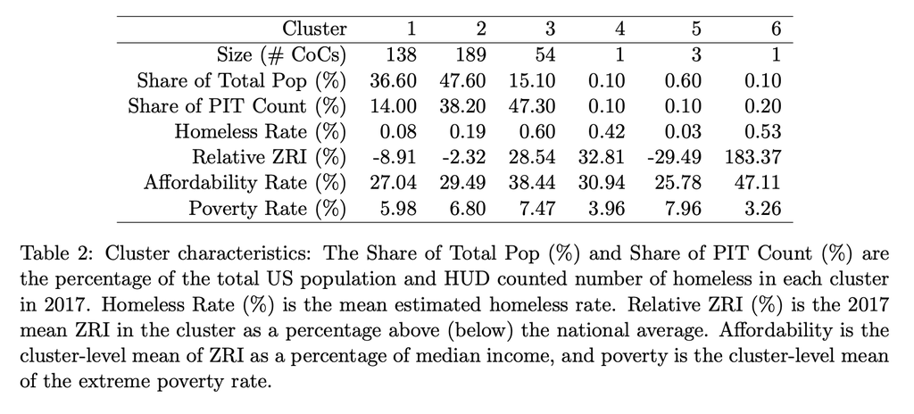

## Sources

- U.S. Department of Housing and Urban Development (HUD) point-in-time counts for homelessness counts
- American Community Survey (ACS) for median household income data and the percent of residents living in extreme poverty
- Zwillo’s rent index (ZRI) for rental costs
- “Hopper et al. (2008) provide evidence that street counts do not fully reflect the size of the homeless population in a community. This systematic undercount of homeless populations artificially lowers homeless rates and necessitates modeling the mechanism by which individuals are excluded from PIT counts.” (p. 6)